# Project 1: EDA & Modeling

Seth Kimpler

Saturday, March 13, 2021 @ 02:43 PM

### Setup

#### Packages Used

Load all packages used in this project.

```r
library(ggplot2)
library(tidyverse)
library(dplyr)
library(moderndive)
```

#### Datasets Used

**Fast Food Dataset**

```r
fast_food_2017 <- read.csv(file = "https://raw.githubusercontent.com/STAT-JET-ASU/Datasets/master/Instructor/fastfood2017.csv")
```

**Cookout Burgers Dataset**

```r
cookout_burgers <- read.csv(file = "https://raw.githubusercontent.com/STAT-JET-ASU/Datasets/master/Instructor/cookoutburgers.csv")
```

**Galton Heights Dataset**

```r
galton_heights <- read.csv(file = "https://raw.githubusercontent.com/STAT-JET-ASU/Datasets/master/Instructor/galtonheightdata.csv")
galton_parent_heights <- read.csv(file = "https://raw.githubusercontent.com/STAT-JET-ASU/Datasets/master/Instructor/galtonparentheights.csv")
```

**Vietnam Draft Dataset**

```r
vietnam_draft <- read.csv(file = "https://raw.githubusercontent.com/STAT-JET-ASU/Datasets/master/Instructor/vietnamdraft.csv")
vietnam_draft_admin <- read.csv(file = "https://raw.githubusercontent.com/STAT-JET-ASU/Datasets/master/Instructor/vietnamdraftadmin.csv")
```

**Names of Collaborators**

List the names of anyone you worked with on this project. If there was no one, put NONE.

Names: NONE

### Fast Food EDA

**The Context**

Nutritionists recommend against eating fast food because it is high in sodium, saturated fat, trans fat, and cholesterol. Eating too much fast food over a long period of time can lead to health problems, such as high blood pressure, heart disease, or obesity. Many fast-food meals contain more than an entire day’s worth of recommended calories and fat! Several websites track the nutritional information of fast food. Read the [description](https://stat-jet-asu.github.io/Datasets/InstructorDescriptions/fastfood2017.html) of two different datasets, which you will use in this analysis and the next. You can access the data files from the description page.

**The Problem**

How much total fat, saturated fat, and trans fat are in some common fast food items? Let’s find out!

**Exploration 1**

Create a frequency table of `restaurant` to discover which fast food restaurants are included in the dataset (and how many total items there are from each restaurant).

```r
table(fast_food_2017$restaurant)
```

```
    Burger King      Carl's Jr.     Chick-fil-A     Dairy Queen        Hardee's
             11              13               5              11              12
In-N-Out Burger Jack in the Box      McDonald's           Sonic         Wendy's
              5              13              11              11              12
    Whataburger    White Castle
             12              10
```

**Exploration 2**

Create a frequency and relative frequency (proportion) table of `type` to discover which categories of fast food items are included in the dataset (and how many there are of each).

```r
table(fast_food_2017$type)
```

```
Breaded Chicken Sandwich                   Burger          Chicken Nuggets
                      11                       69                       11
            French Fries Grilled Chicken Sandwich                Milkshake
                      12                       11                       12
```

```r
prop.table(table(fast_food_2017$type))
```

```
Breaded Chicken Sandwich                   Burger          Chicken Nuggets
              0.08730159               0.54761905               0.08730159
            French Fries Grilled Chicken Sandwich                Milkshake
              0.09523810               0.08730159               0.09523810
```

**Exploration 3**

Create a horizontal barplot of `type` to visualize which categories of fast food items are included in the dataset (and how many total items there are of each type).

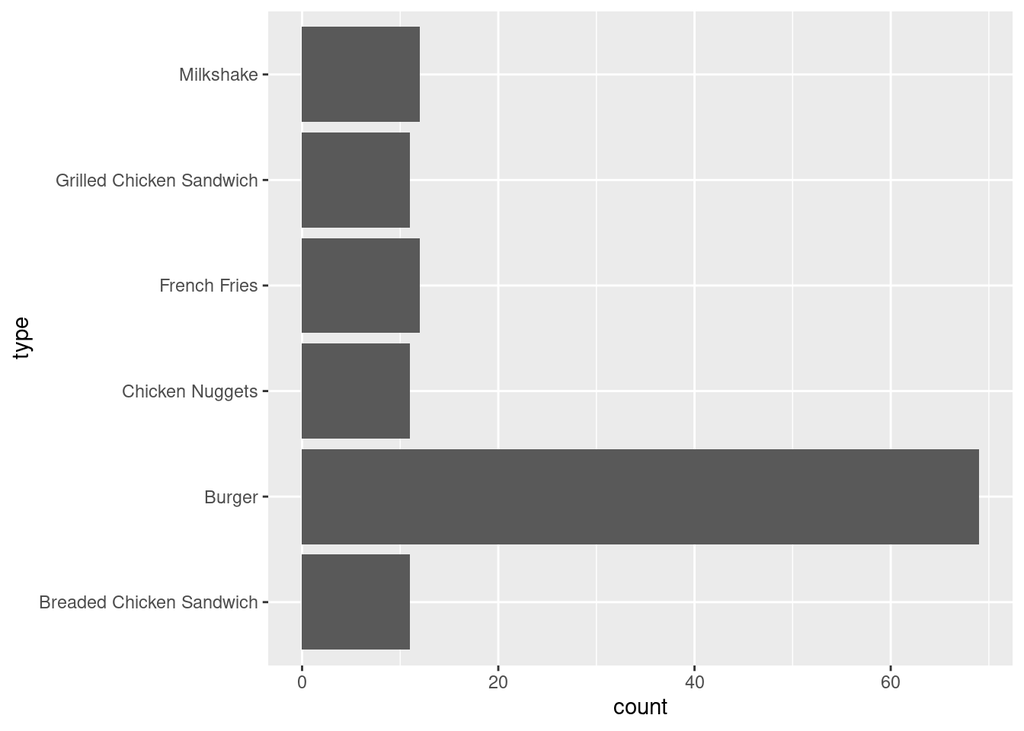

```r
ggplot(fast_food_2017, aes(x=type)) + geom_bar() + coord_flip()
```

**Exploration 4**

Compute n, mean, and standard deviation for `totalfat` by `type` and sort by descending mean.

```r
fast_food_2017 %>%
  group_by(type) %>%
  summarize(n = n(), mean = mean(totalfat), standard_deviation = sd(totalfat)) %>%
  arrange(desc(mean))
```

```
# A tibble: 6 x 4
  type                         n  mean standard_deviation
  <chr>                    <int> <dbl>              <dbl>
1 Burger                      69  35.9              20.4
2 Breaded Chicken Sandwich    11  26.0               9.20
3 Milkshake                   12  22.6              10.4
4 Chicken Nuggets             11  17.4              11.0
5 Grilled Chicken Sandwich    11  17                 9.66
6 French Fries                12  15.3               2.78
```

**Exploration 5**

Compute n, mean, and standard deviation for `saturatedfat` by `type` and sort by descending mean.

```r
fast_food_2017 %>%
  group_by(type) %>%
  summarize(n = n(), mean = mean(saturatedfat), standard_deviation = sd(saturatedfat)) %>%
  arrange(desc(mean))
```

```
# A tibble: 6 x 4
  type                         n  mean standard_deviation
  <chr>                    <int> <dbl>              <dbl>
1 Milkshake                   12 15.2                7.61
2 Burger                      69 13.6                7.69
3 Breaded Chicken Sandwich    11  4.56               1.86
4 Grilled Chicken Sandwich    11  3.86               2.92
5 Chicken Nuggets             11  3.05               2.20
6 French Fries                12  2.89               1.20
```

**Exploration 6**

Compute n, mean, and standard deviation for `transfat` by `type` and sort by descending mean.

```r
fast_food_2017 %>%
  group_by(type) %>%
  summarize(n = n(), mean = mean(transfat, na.rm=TRUE), standard_deviation = sd(transfat, na.rm=TRUE)) %>%
  arrange(desc(mean))
```

```
# A tibble: 6 x 4
  type                         n  mean standard_deviation
  <chr>                    <int> <dbl>              <dbl>
1 Burger                      69 1.38              0.950
2 Milkshake                   12 0.591             0.625
3 French Fries                12 0.1               0.3
4 Grilled Chicken Sandwich    11 0.04              0.126
5 Breaded Chicken Sandwich    11 0.01              0.0316
6 Chicken Nuggets             11 0.01              0.0316
```

**Discussion**

Question 1: According to US dietary guidelines, if you are following a standard 2000-calorie per day diet, your target range for total fat is 44 to 78 grams, with no more than 22 grams of saturated fat and no more than 2 grams of trans fat. Consider your summaries of the different kinds of fat in the different types of foods included in this sample. Fat values for each item were recorded on a per-serving basis. Which type of item seems to be the most unhealthy when considering all three kinds of fat? Explain.

Question 2: In terms of the number of locations, McDonalds, Burger King, and Wendy’s are the largest burger-selling chains in the United States. However, it is also true that Hardee’s and Carl’s Jr. are essentially the same chain with the same menu, just with different names in the eastern versus western United States. Given the restaurants and items included in this sample, do you feel that the data is generally representative of the population of fast food items in the United States? If not, what does it represent? Explain.

### Fast Food Model

You will use the same datasets here that you read about and/or used in the **Fast Food EDA** problem.

**The Problem**

Many fast food menus now display the calorie counts for different items. Can we accurately predict the total amount of fat in fast food burgers from the number of calories?

**Data Reduction**

Create a dataset called `ffburgers` that contains only the observations for fast food burgers.

```r
ffburgers <- fast_food_2017 %>%
                filter(type=="Burger")
```

**Variable Renaming**

In the Cookout burgers dataset, rename the variable `fat` to `totalfat` to match the `ffburgers` dataset.

```r
cookout_burgers <- cookout_burgers %>%
                    rename(totalfat = fat)
```

**Linear Modeling**

We want to predict total fat using a least-squares linear function of total calories.

The Plot

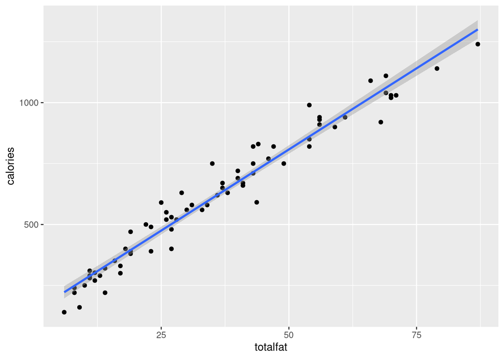

```r
ggplot(ffburgers, aes(x=totalfat, y=calories)) + geom_point() + geom_smooth(method='lm')
```

The Model

```r
model <- lm(totalfat ~ calories, data=ffburgers)
get_regression_summaries(model)
```

```
# A tibble: 1 x 9
  r_squared adj_r_squared   mse  rmse sigma statistic p_value    df  nobs
      <dbl>         <dbl> <dbl> <dbl> <dbl>     <dbl>   <dbl> <dbl> <dbl>
1     0.956         0.955  18.0  4.24  4.30     1456.       0     1    69
```

**Test Predictions**

Test your ability to generalize your model by using it to predict the amount of fat in the four Cookout burgers, which were not part of the original dataset you used to create the model.

```r
vals <- cookout_burgers %>% select(calories)
get_regression_points(model, newdata=vals) %>%
  rename(predicted_total_fat = totalfat_hat)
```

```
# A tibble: 4 x 3
     ID calories predicted_total_fat
  <int>    <int>               <dbl>
1     1      230                7.89
2     2      330               15.1
3     3      510               28.0
4     4      310               13.6
```

**Discussion of Results**

Question 1: How do the residuals from the Cookout burger predictions compare to typical residuals from the fitted model? Explain.

Question 2: Based on the residuals and residual summaries, does it seem as if we can we accurately predict the total amount of fat in fast food burgers from the number of calories? Explain.

### Galton EDA

**The Context**

Francis Galton, a cousin of Charles Darwin, studied the relationship between parent heights and the heights of their offspring. His pioneering [1886 article](https://galton.org/essays/1880-1889/galton-1886-jaigi-regression-stature.pdf) is the first appearance of regression analysis in print. He originated many statistical terms and concepts, including regression, correlation, deviate, quartile, and percentile, plus median for the midpoint of a distribution. His colleague and frequent collaborator Karl Pearson developed the Pearson product-moment correlation coefficient from the work of Galton and Auguste Bravais. The `galtonheightdata` dataset was [created under the direction of Dr. James A. Hanley](http://www.medicine.mcgill.ca/epidemiology/hanley/galton/) using Galton’s original paper notebooks. The “female statures” are in their raw (untransmuted) form. You can access the data file from the [description](https://stat-jet-asu.github.io/Datasets/InstructorDescriptions/galtonheightdata.html) page.

**The Problem**

As one of his many genetic studies, Galton compared the heights of children to the heights of their parents. Before this analysis, he multiplied all of the female children’s heights by 1.08. About this data transformation, Galton explained, “In every case I transmuted the female statures to their corresponding male equivalents and used them in their transmuted form, so that no objection grounded on the sexual difference of stature need be raised when I speak of averages.” What is the impact on the distributions of children’s heights when Galton’s “transmutation” is used?

**Data Transformation**

Create a new variable in the dataset named `HeightT` by “transmuting” the `Height` variable such that female heights are multiplied by 1.08 while male heights remain the same.

```r
galton_heights <- galton_heights %>%
                    mutate(HeightT = if_else(Gender == "Female", Height * 1.08, Height))
```

**Exploration 1**

Compute summary statistics (n, mean, standard deviation, five-number summary, IQR, and range) for `Height` by `Gender` so you can compare the two groups.

```r
galton_heights %>%
  group_by(Gender) %>%
  summarize(n = n(), mean = mean(Height), standard_deviation = sd(Height), fivenum(Height), IQR = IQR(Height), range = diff(range(Height)))
```

```
# A tibble: 10 x 7
# Groups:   Gender [2]
   Gender     n  mean standard_deviation `fivenum(Height)`   IQR range
   <chr>  <int> <dbl>              <dbl>             <dbl> <dbl> <dbl>
 1 Female   433  64.1               2.37              56     3    14.5
 2 Female   433  64.1               2.37              62.5   3    14.5
 3 Female   433  64.1               2.37              64     3    14.5
 4 Female   433  64.1               2.37              65.5   3    14.5
 5 Female   433  64.1               2.37              70.5   3    14.5
 6 Male     465  69.2               2.63              60     3.5  19
 7 Male     465  69.2               2.63              67.5   3.5  19
 8 Male     465  69.2               2.63              69.2   3.5  19
 9 Male     465  69.2               2.63              71     3.5  19
10 Male     465  69.2               2.63              79     3.5  19
```

**Exploration 2**

Create a density plot with `color = Gender` in the aesthetics to show overlapping densities for measured heights of male and female children.

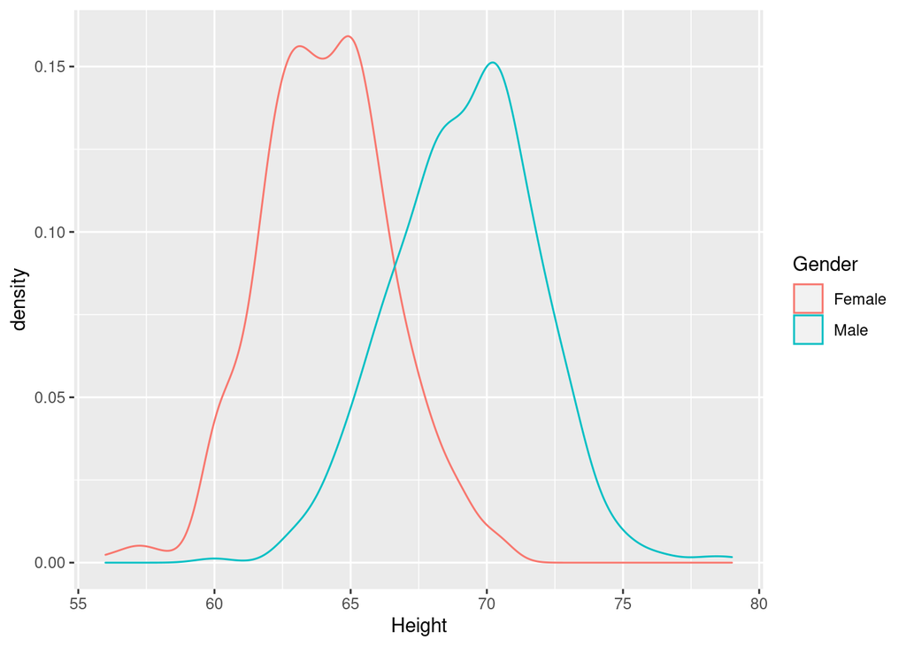

```r
ggplot(galton_heights %>% group_by(Gender), aes(x = Height, color = Gender)) + geom_density()
```

**Exploration 3**

Compute summary statistics (n, mean, standard deviation, five-number summary, IQR, and range) for `HeightT` by `Gender` so you can compare the two groups.

```r
galton_heights %>%
  group_by(Gender) %>%
  summarize(n = n(), mean = mean(HeightT), standard_deviation = sd(HeightT), fivenum(HeightT), IQR = IQR(HeightT), range = diff(range(HeightT)))
```

```
# A tibble: 10 x 7
# Groups:   Gender [2]
   Gender     n  mean standard_deviation `fivenum(HeightT)`   IQR range
   <chr>  <int> <dbl>              <dbl>              <dbl> <dbl> <dbl>
 1 Female   433  69.2               2.56               60.5  3.24  15.7
 2 Female   433  69.2               2.56               67.5  3.24  15.7
 3 Female   433  69.2               2.56               69.1  3.24  15.7
 4 Female   433  69.2               2.56               70.7  3.24  15.7
 5 Female   433  69.2               2.56               76.1  3.24  15.7
 6 Male     465  69.2               2.63               60    3.5   19
 7 Male     465  69.2               2.63               67.5  3.5   19
 8 Male     465  69.2               2.63               69.2  3.5   19
 9 Male     465  69.2               2.63               71    3.5   19
10 Male     465  69.2               2.63               79    3.5   19
```

**Exploration 4**

Create a density plot with `color = Gender` in the aesthetics to show overlapping densities for transmuted heights of male and female children.

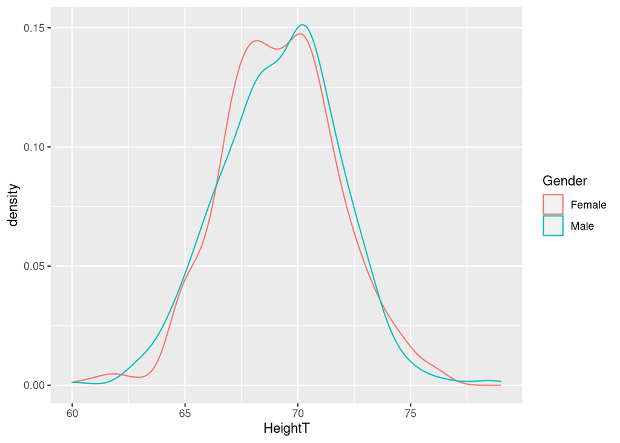

```r
ggplot(galton_heights %>% group_by(Gender), aes(x = HeightT, color = Gender)) + geom_density()
```

**Exploration 5**

In general, when we transform data via multiplication by a constant, the mean and standard deviation of the transformed data are the same as if we multiplied the mean and standard deviation of the original data by the same constant. Show that this is true, either in this case using the data for female children, or algebraically using the formulas for mean and standard deviation.

```r
galton_heights %>%
  filter(Gender == "Female") %>%
  summarize(mean_height = mean(Height), sd_height = sd(Height), mean_heightT = mean(HeightT), sd_heightT = sd(HeightT))
```

```
  mean_height sd_height mean_heightT sd_heightT
1    64.11016   2.37032     69.23897   2.559945
```

**Discussion of Results**

Was Galton’s “transmutation” successful in essentially eliminating “the sexual difference of stature” in his dataset? Explain using information from both the summaries and the plots.

### Galton Model

Here you will use the dataset with transmuted height that you created in **Galton EDA**.

**The Problem**

So, about that modeling…what can we learn about the relationship between offspring height and parent height?

**Data Transformation**

Create a new variable in the dataset named `Midparent` that contains the average of mother and father heights for each observation.

```r
galton_heights <- galton_heights %>%
                    mutate(Midparent = (Father + Mother) / 2)
```

**Linear Modeling**

Galton sought to explain children’s heights using their parents’ heights (represented by the parental midpoint). You will conduct an analysis that is similar in intent but not mathematically identical—Galton did not use the least-squares method of line fitting. Use the children’s transmuted heights and the parent mid-height as your model variables.

The Plot

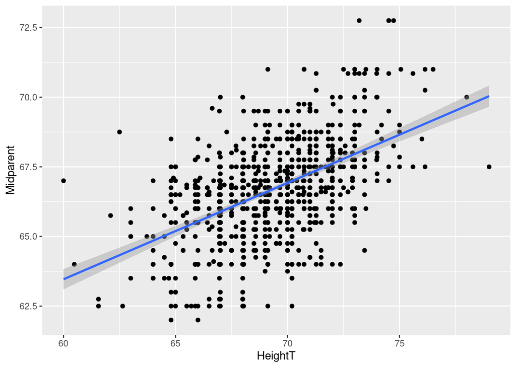

```r
ggplot(galton_heights, aes(x = HeightT, y = Midparent)) +
  geom_point() +
  geom_smooth(method = "lm")
```

The Model

```r
model <- lm(HeightT ~ Midparent, data=galton_heights)
get_regression_summaries(model)
```

```
# A tibble: 1 x 9
  r_squared adj_r_squared   mse  rmse sigma statistic p_value    df  nobs
      <dbl>         <dbl> <dbl> <dbl> <dbl>     <dbl>   <dbl> <dbl> <dbl>
1     0.263         0.262  4.96  2.23  2.23      320.       0     1   898
```

**Test Predictions**

```r
vals <- galton_heights %>% select(Midparent)
get_regression_points(model, newdata=vals) %>%
  rename(predicted_HeightT = HeightT_hat)
```

```
# A tibble: 898 x 3
      ID Midparent predicted_HeightT
   <int>     <dbl>             <dbl>
 1     1      72.8              73.9
 2     2      72.8              73.9
 3     3      72.8              73.9
 4     4      72.8              73.9
 5     5      71                72.5
 6     6      71                72.5
 7     7      71                72.5
 8     8      71                72.5
 9     9      69.5              71.4
10    10      69.5              71.4
# … with 888 more rows
```

**Discussion of Results**

Question 1: According to Galton, height was a good measurement to study because it is easy to obtain and, being the sum of more than a hundred individual body parts (e.g., legs, spine, skull), was resistant to variation in any one of the component parts. Overall, how much of the variation in offspring heights is *not* explained by average parent heights? What are some other factors that could explain the “error” variation in the offspring heights in the dataset and large differences in prediction like we saw?

Question 2: One assumption of least squares regression analysis is that all of the the observations are independent. In this case, that means each row of the dataset should be independent of (unrelated to) every other row of the dataset. Is that true in this case? Explain.